# Forecasting project 2

### Forecasting predictors using TSLM (regression)

I will finally use a TSLM model to forecast the weather data, starting with predicting the temperature based on the rest of the weather data values.

```r
#TEMPERATURE


#Fitting the TSLM model
temp_tslm <- ts_data %>%
  model(tslm = TSLM(temp ~ precip + windspeed + humidity))
report(temp_tslm)
```

```
## Series: temp
## Model: TSLM
##
## Residuals:
##      Min       1Q   Median       3Q      Max
## -17.3965  -5.0338   0.3469   5.2460  12.7862
##
## Coefficients:
##             Estimate Std. Error t value Pr(>|t|)
## (Intercept) 38.45844    1.42967  26.900  < 2e-16 ***
## precip       0.30007    0.02994  10.024  < 2e-16 ***
## windspeed   -0.19033    0.02912  -6.536 8.83e-11 ***
## humidity    -0.34148    0.01637 -20.854  < 2e-16 ***
## ---
## Signif. codes:  0 '***' 0.001 '**' 0.01 '*' 0.05 '.' 0.1 ' ' 1
##
## Residual standard error: 6.284 on 1408 degrees of freedom
## Multiple R-squared: 0.2389,  Adjusted R-squared: 0.2373
## F-statistic: 147.4 on 3 and 1408 DF, p-value: < 2.22e-16
```

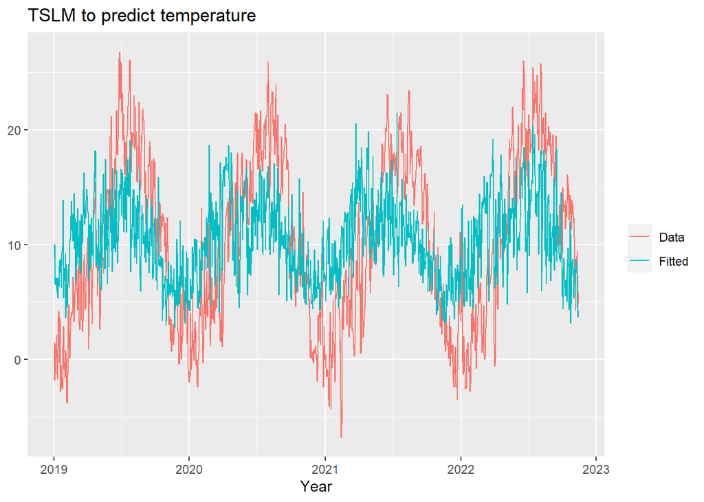

```r
#Plotting the TSLM model
augment(temp_tslm) %>%
  ggplot(aes(x = Date)) +
  geom_line(aes(y = temp, colour = "Data")) +
  geom_line(aes(y = .fitted, colour = "Fitted")) + xlab("Year") + ylab(NULL) +
  guides(colour = guide_legend(title=NULL)) +
  labs(title = "TSLM to predict temperature")
```

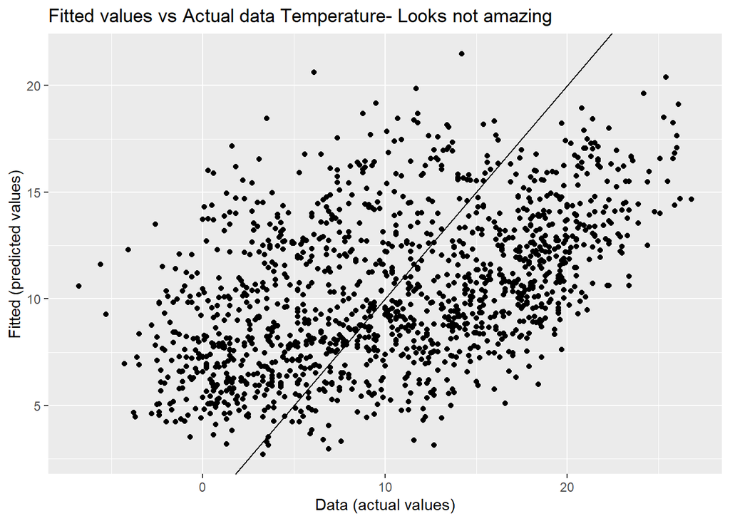

```r
#comparing the TSLM model with actual data to see how good/bad it is
augment(temp_tslm) %>%
  ggplot(aes(x = temp, y = .fitted)) + geom_point() +
  ylab("Fitted (predicted values)") + xlab("Data (actual values)") +
  geom_abline(intercept = 0, slope = 1) +
  labs(title = "Fitted values vs Actual data Temperature- Looks not amazing")
```

```r
#Getting the metrics
glance(temp_tslm) %>% dplyr::select(adj_r_squared, CV, AIC, AICc, BIC)
```

```
## # A tibble: 1 × 5
##   adj_r_squared    CV   AIC  AICc   BIC
##           <dbl> <dbl> <dbl> <dbl> <dbl>
## 1         0.237  39.6 5196. 5196. 5223.
```

```r
#Getting the Forecast for November 2022:
forecast_tslm_temp <- temp_tslm %>% forecast(new_data = ts_data_weather_te, h = 15)
```

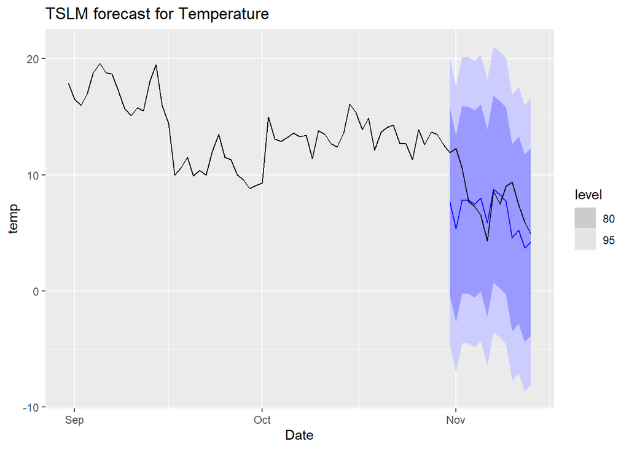

```r
forecast_tslm_temp %>% autoplot(ts_data_weather_last6) + labs(title = "TSLM forecast for Temperature")
```

```r
#Extracting the forecast values:
forecast_table_tslm_temp <- as.data.frame(forecast_tslm_temp)
forecast_table_tslm_temp <- forecast_table_tslm_temp %>% select(Date,.mean)

#change col names
colnames(forecast_table_tslm_temp)[1] <- "Date"
colnames(forecast_table_tslm_temp)[2] <- "Temp TSLM"

#IGNORE THIS:

#%>% autoplot(ts_data_weather_last6)+
#  labs(title = "SARIMA Forecast for Temperature")

#Getting the forecasts (HERE I USE A DIFFERENT FIT)
#temp_fit <- ts_data_weather_tr2 %>% model(TSLM(temp ~ trend() + season()))
#temp_tslm_fc <- forecast(temp_fit)
#plottingthe forecast
#temp_tslm_fc %>% autoplot(ts_data_weather_last6) + xlab("Day") + ylab("Price")


#Getting the original forecast
#forecast_tslm <- temp_tslm %>%
#  forecast(new_data = ts_data_weather_last6, h = 15)
#forecast_tslm %>% autoplot(ts_data_weather_last6)
```

Since this looks much better than what I was getting using SARIMA and ETS, I will use TSLM to forecast all of my predictor variables. At the moment, I don’t have a metric to compare TSLM with ETS and SARIMA, I simply use my intuition based on the graph produced above. It clearly captured the usual drop in temperatures in November, whereas ETS and SARIMA produced a flat forecast.

```r
#PRECIPITATION


#Fitting the TSLM model
precip_tslm <- ts_data %>%
  model(tslm = TSLM(precip ~ temp + windspeed + humidity))
report(precip_tslm)
```

```
## Series: precip
## Model: TSLM
##
## Residuals:
##    Min     1Q Median     3Q    Max
## -8.014 -3.126 -1.172  1.252 45.830
##
## Coefficients:
##              Estimate Std. Error t value Pr(>|t|)
## (Intercept) -23.34796    1.37913  -16.93   <2e-16 ***
## temp          0.22199    0.02215   10.02   <2e-16 ***
## windspeed     0.25622    0.02449   10.46   <2e-16 ***
## humidity      0.26373    0.01450   18.19   <2e-16 ***
## ---
## Signif. codes:  0 '***' 0.001 '**' 0.01 '*' 0.05 '.' 0.1 ' ' 1
##
## Residual standard error: 5.405 on 1408 degrees of freedom
## Multiple R-squared: 0.2061,  Adjusted R-squared: 0.2044
## F-statistic: 121.8 on 3 and 1408 DF, p-value: < 2.22e-16
```

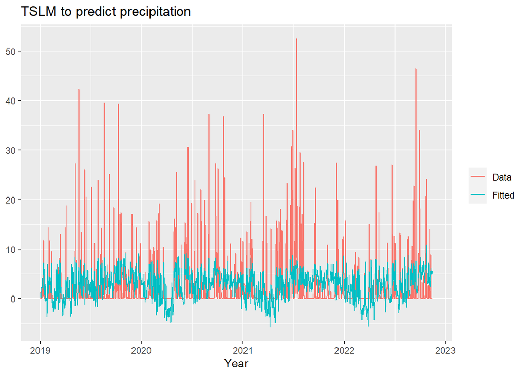

```r
#Plotting the TSLM model
augment(precip_tslm) %>%
  ggplot(aes(x = Date)) +
  geom_line(aes(y = precip, colour = "Data")) +
  geom_line(aes(y = .fitted, colour = "Fitted")) + xlab("Year") + ylab(NULL) +
  guides(colour = guide_legend(title=NULL)) +
  labs(title = "TSLM to predict precipitation")
```

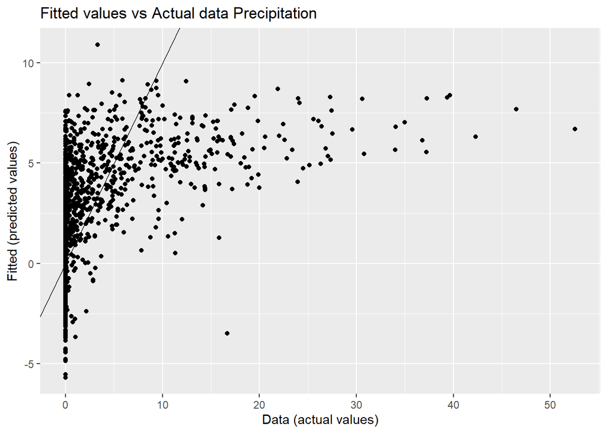

```r
#comparing the TSLM model with actual data to see how good/bad it is
augment(precip_tslm) %>%
  ggplot(aes(x = precip, y = .fitted)) + geom_point() +
  ylab("Fitted (predicted values)") + xlab("Data (actual values)") +
  geom_abline(intercept = 0, slope = 1) +
  labs(title = "Fitted values vs Actual data Precipitation")
```

```r
#Getting the metrics
glance(precip_tslm) %>% dplyr::select(adj_r_squared, CV, AIC, AICc, BIC)
```

```
## # A tibble: 1 × 5
##   adj_r_squared    CV   AIC  AICc   BIC
##           <dbl> <dbl> <dbl> <dbl> <dbl>
## 1         0.204  29.3 4771. 4771. 4797.
```

```r
#Getting the Forecast for November 2022:
forecast_tslm_precip <- precip_tslm %>% forecast(new_data = ts_data_weather_te, h = 15)
```

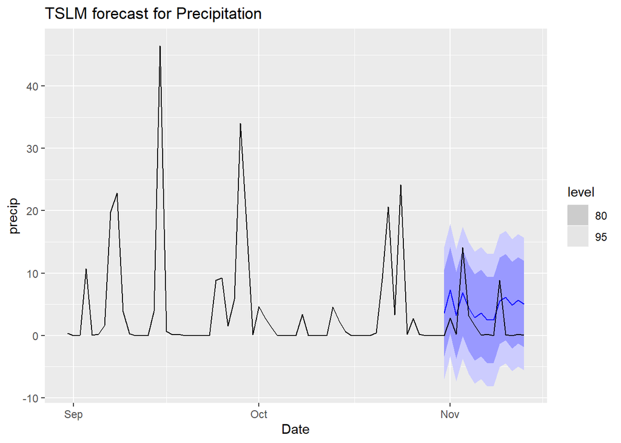

```r
forecast_tslm_precip %>% autoplot(ts_data_weather_last6) + labs(title = "TSLM forecast for Precipitation")
```

```r
#Extracting the forecast values:
forecast_table_tslm_precip <- as.data.frame(forecast_tslm_precip)
forecast_table_tslm_precip <- forecast_table_tslm_precip %>% select(Date,.mean)

#change col names
colnames(forecast_table_tslm_precip)[1] <- "Date"
colnames(forecast_table_tslm_precip)[2] <- "Precip TSLM"
```

```r
#WINDSPEED


#Fitting the TSLM model
windspeed_tslm <- ts_data %>%
  model(tslm = TSLM(windspeed ~ temp + precip + humidity))
report(windspeed_tslm)
```

```
## Series: windspeed
## Model: TSLM
##
## Residuals:
##      Min       1Q   Median       3Q      Max
## -14.1921  -3.9525  -0.9571   2.7887  27.3114
##
## Coefficients:
##             Estimate Std. Error t value Pr(>|t|)
## (Intercept) 33.10556    1.31785  25.121  < 2e-16 ***
## temp        -0.15470    0.02367  -6.536 8.83e-11 ***
## precip       0.28151    0.02691  10.462  < 2e-16 ***
## humidity    -0.23751    0.01566 -15.169  < 2e-16 ***
## ---
## Signif. codes:  0 '***' 0.001 '**' 0.01 '*' 0.05 '.' 0.1 ' ' 1
##
## Residual standard error: 5.665 on 1408 degrees of freedom
## Multiple R-squared: 0.1545,  Adjusted R-squared: 0.1527
## F-statistic: 85.73 on 3 and 1408 DF, p-value: < 2.22e-16
```

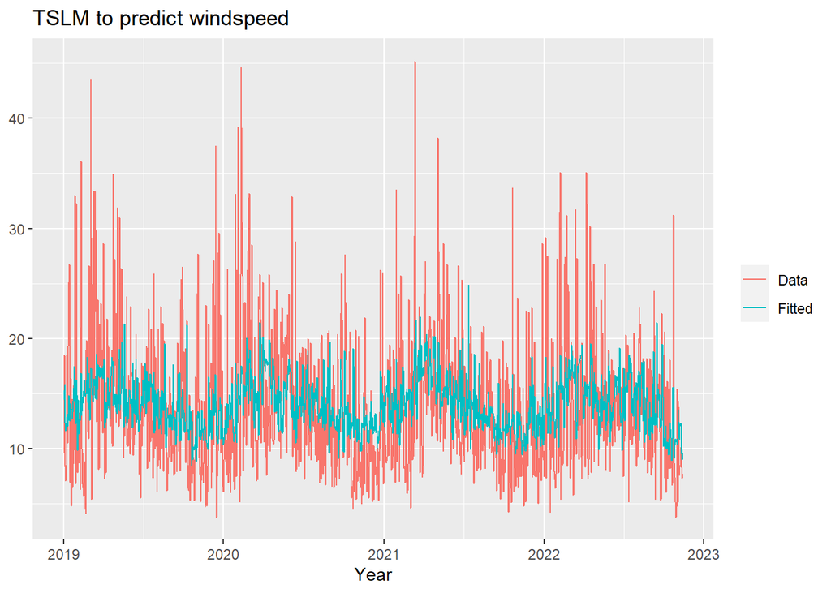

```r
#Plotting the TSLM model
augment(windspeed_tslm) %>%
  ggplot(aes(x = Date)) +
  geom_line(aes(y = windspeed, colour = "Data")) +
  geom_line(aes(y = .fitted, colour = "Fitted")) + xlab("Year") + ylab(NULL) +
  guides(colour = guide_legend(title=NULL)) +
  labs(title = "TSLM to predict windspeed")
```

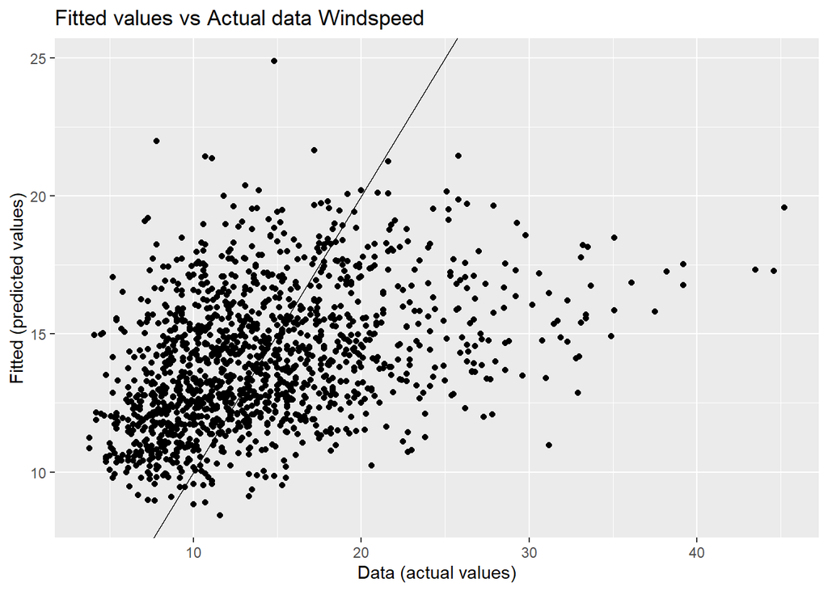

```r
#comparing the TSLM model with actual data to see how good/bad it is
augment(windspeed_tslm) %>%
  ggplot(aes(x = windspeed, y = .fitted)) + geom_point() +
  ylab("Fitted (predicted values)") + xlab("Data (actual values)") +
  geom_abline(intercept = 0, slope = 1) +
  labs(title = "Fitted values vs Actual data Windspeed")
```

```r
#Getting the metrics
glance(windspeed_tslm) %>% dplyr::select(adj_r_squared, CV, AIC, AICc, BIC)
```

```
## # A tibble: 1 × 5
##   adj_r_squared    CV   AIC  AICc   BIC
##           <dbl> <dbl> <dbl> <dbl> <dbl>
## 1         0.153  32.2 4904. 4904. 4930.
```

```r
#Getting the Forecast for November 2022:
forecast_tslm_windspeed <- windspeed_tslm %>% forecast(new_data = ts_data_weather_te, h = 15)
```

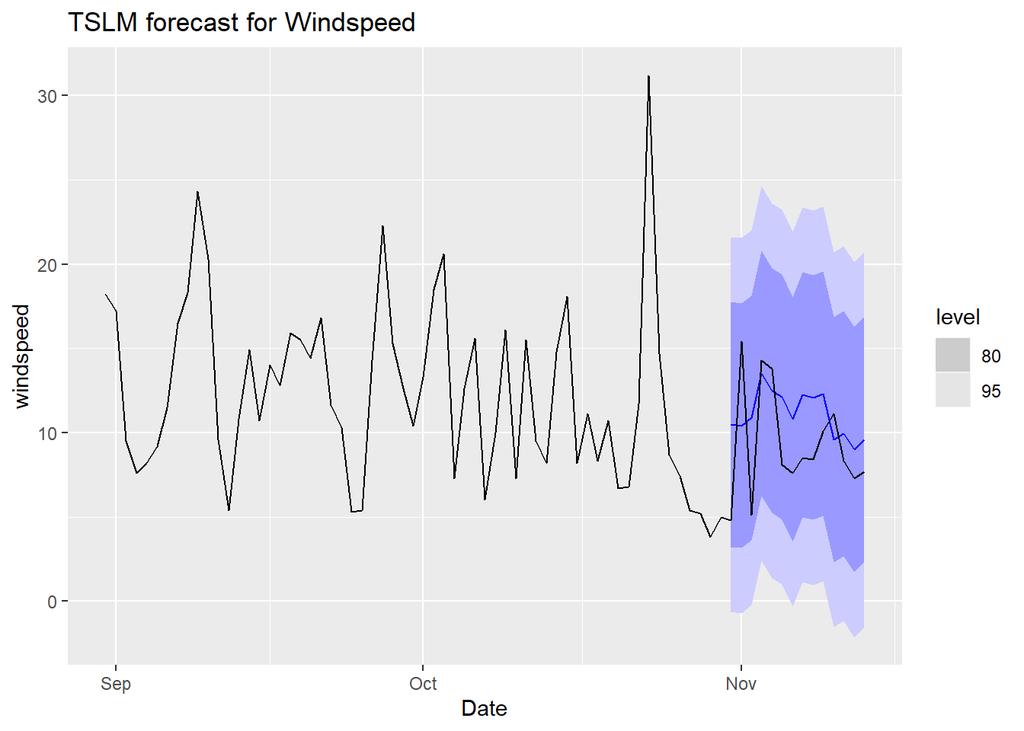

```r
forecast_tslm_windspeed %>% autoplot(ts_data_weather_last6) + labs(title = "TSLM forecast for Windspeed")
```

```r
#Extracting the forecast values:
forecast_table_tslm_windspeed <- as.data.frame(forecast_tslm_windspeed)
forecast_table_tslm_windspeed <- forecast_table_tslm_windspeed %>% select(Date,.mean)

#change col names
colnames(forecast_table_tslm_windspeed)[1] <- "Date"
colnames(forecast_table_tslm_windspeed)[2] <- "Windspeed TSLM"
```

```r
#HUMIDITY


#Fitting the TSLM model
humidity_tslm <- ts_data %>%
  model(tslm = TSLM(humidity ~ temp + precip + windspeed))
report(humidity_tslm)
```

```
## Series: humidity
## Model: TSLM
##
## Residuals:
##     Min      1Q  Median      3Q     Max
## -30.992  -6.007   1.492   6.637  23.357
##
## Coefficients:
##             Estimate Std. Error t value Pr(>|t|)
## (Intercept) 90.37837    0.67890  133.12   <2e-16 ***
## temp        -0.69106    0.03314  -20.85   <2e-16 ***
## precip       0.72146    0.03966   18.19   <2e-16 ***
## windspeed   -0.59137    0.03899  -15.17   <2e-16 ***
## ---
## Signif. codes:  0 '***' 0.001 '**' 0.01 '*' 0.05 '.' 0.1 ' ' 1
##
## Residual standard error: 8.939 on 1408 degrees of freedom
## Multiple R-squared: 0.3907,  Adjusted R-squared: 0.3894
## F-statistic:   301 on 3 and 1408 DF, p-value: < 2.22e-16
```

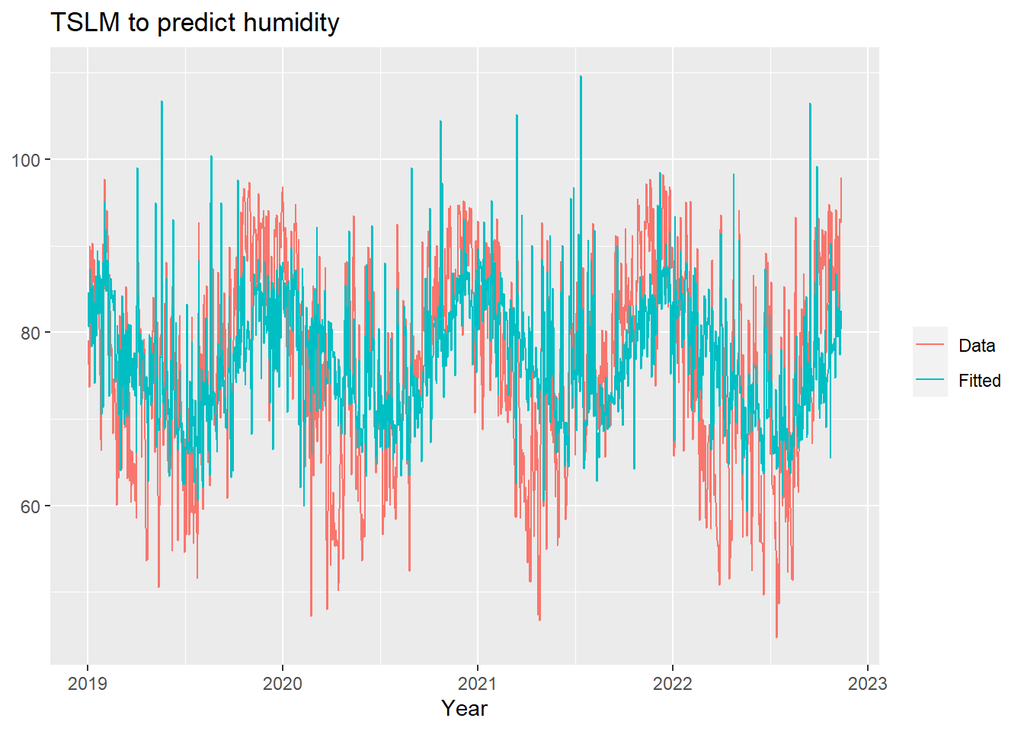

```r
#Plotting the TSLM model
augment(humidity_tslm) %>%
  ggplot(aes(x = Date)) +
  geom_line(aes(y = humidity, colour = "Data")) +
  geom_line(aes(y = .fitted, colour = "Fitted")) + xlab("Year") + ylab(NULL) +
  guides(colour = guide_legend(title=NULL)) +
  labs(title = "TSLM to predict humidity")
```

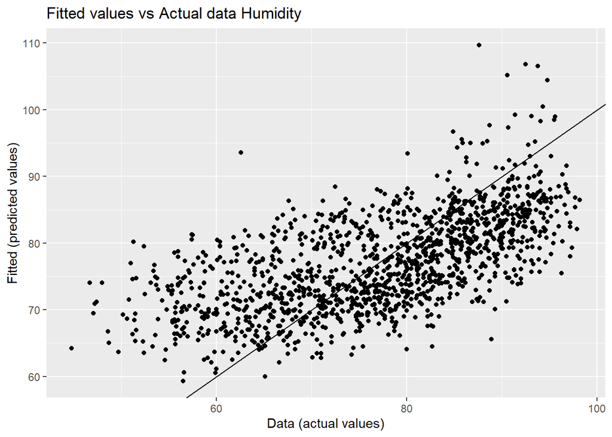

```r
#comparing the TSLM model with actual data to see how good/bad it is
augment(humidity_tslm) %>%
  ggplot(aes(x = humidity, y = .fitted)) + geom_point() +
  ylab("Fitted (predicted values)") + xlab("Data (actual values)") +
  geom_abline(intercept = 0, slope = 1) +
  labs(title = "Fitted values vs Actual data Humidity")
```

```r
#Getting the metrics
glance(humidity_tslm) %>% dplyr::select(adj_r_squared, CV, AIC, AICc, BIC)
```

```
## # A tibble: 1 × 5
##   adj_r_squared    CV   AIC  AICc   BIC
##           <dbl> <dbl> <dbl> <dbl> <dbl>
## 1         0.389  80.1 6192. 6192. 6218.
```

```r
#Getting the Forecast for November 2022:
forecast_tslm_humidity <- humidity_tslm %>% forecast(new_data = ts_data_weather_te, h = 15)
```

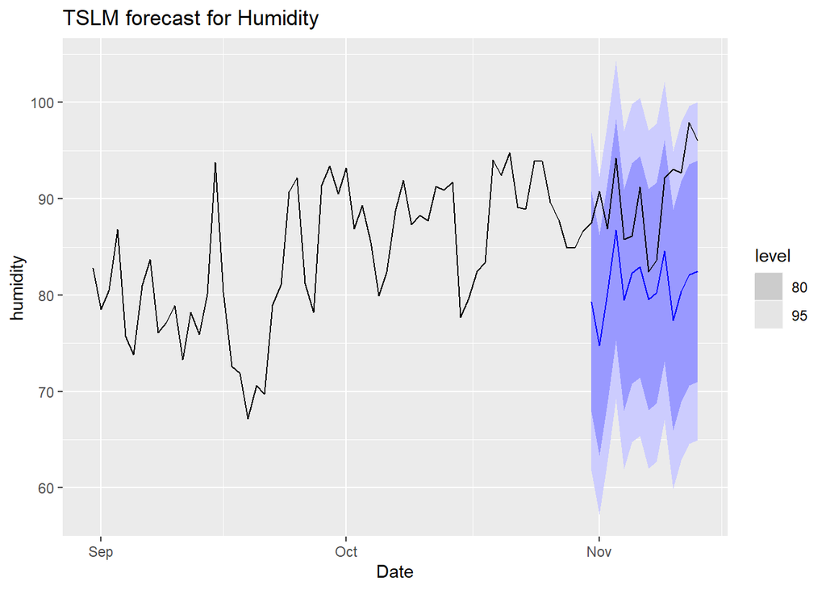

```r
forecast_tslm_humidity %>% autoplot(ts_data_weather_last6) + labs(title = "TSLM forecast for Humidity")
```

```r
#Extracting the forecast values:
forecast_table_tslm_humidity <- as.data.frame(forecast_tslm_humidity)
forecast_table_tslm_humidity <- forecast_table_tslm_humidity %>% select(Date,.mean)

#change col names
colnames(forecast_table_tslm_humidity)[1] <- "Date"
colnames(forecast_table_tslm_humidity)[2] <- "Humidity TSLM"
```

At this point we have forecasts for all of our weather covariates: temperature, precipitation, windspeed and humidity.

I decided to use TSLM because ETS and SARIMA produced complete garbage.

# Forecasting Flights

After having forecasted and selected our covariates, it’s time to forecast the number of flights.

First, let’s create a table that contains all the forecasts from our covariates:

```r
#Join all covariate forecast tables together
cov_fc <- left_join(forecast_table_tslm_temp, forecast_table_tslm_precip, by = "Date")
cov_fc <- left_join(cov_fc, forecast_table_tslm_windspeed, by = "Date")
cov_fc <- left_join(cov_fc, forecast_table_tslm_humidity, by = "Date")

# round columns 2 to 5 to 2 decimals
cov_fc <- cov_fc %>%
  mutate_at(vars(2:5), ~ round(., 2))
```